# Global warming through data

## Creative challenge

Design your own piece of climate data art using the same dataset.

You are free to experiment with geometric shapes, color palettes, transparency, repetition, coordinate transformations, and visual composition.

Create an original visualization using `ggplot2` and the NASA GISTEMP dataset.

Your artwork should satisfy three requirements:

1. It must be generated programmatically from the dataset, rather than manually illustrated.
2. At least one visual property (color, size, position, shape, or opacity) must encode a numerical variable.
3. The visual composition must communicate a meaningful aspect of global warming.

You may remove conventional statistical elements such as axes, titles, legends, and labels, but you must document how the data are mapped to the artwork.

### Setup

```r
library(tidyverse)

url <- paste0(
  "https://data.giss.nasa.gov/gistemp/",
  "tabledata_v4/GLB.Ts+dSST.csv"
)

temp_raw <- read_csv(
  url,
  skip = 1,
  na = c("***", "****"),
  show_col_types = FALSE
)
```

```r
temp <- temp_raw |>
  select(Year, Jan:Dec) |>
  pivot_longer(
    cols = Jan:Dec,
    names_to = "month",
    values_to = "anomaly"
  ) |>
  mutate(
    month = factor(month, levels = month.abb),
    date = as.Date(
      paste(Year, month, "01", sep = "-"),
      format = "%Y-%b-%d"
    )
  ) |>
  drop_na(anomaly)

head(temp, n = 12)
```

[output not shown]

### Climate data art: *The Climate Spirograph*

Instead of a traditional time series, rectangular grid, or circular spiral, we can arrange temperature anomalies as a geometric **spirograph**.

In a spirograph, a smaller circle rolls inside a larger fixed circle. The trajectory of a drawing point at distance d from the rolling center traces harmonious orbital loops.

Here, the temperature anomaly directly controls the **reach of the pen (d)**: - **Colder years (blue)** keep the pen tight, forming compact internal orbits. - **Warmer years (red)** push the pen farther out, causing the petals to expand outward as the climate warms over time.

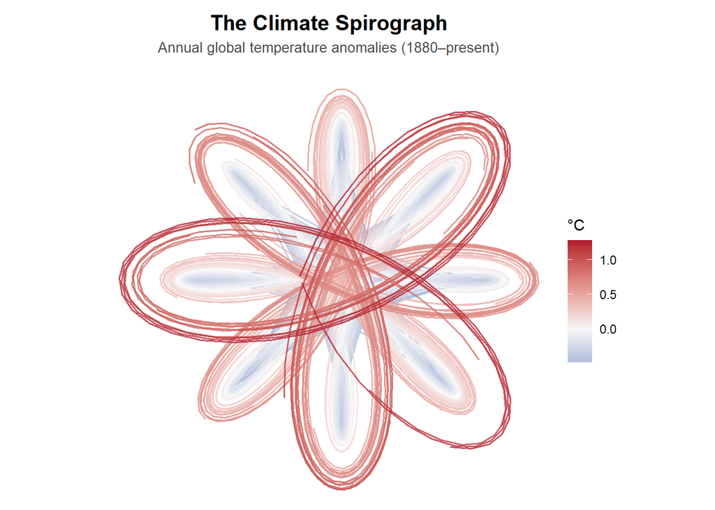

```r
annual_spiro <- temp |>
  group_by(Year) |>
  summarise(anomaly = mean(anomaly), .groups = "drop") |>
  mutate(
    year_idx = row_number(),
    theta_start = (year_idx - 1) * (2 * pi / 14.5)
  )

spiro_points <- annual_spiro |>
  reframe(
    {
      t_seq <- seq(theta_start, theta_start + 2 * pi, length.out = 50)
      R <- 8
      r <- 3
      d <- 4 + anomaly * 2.5
      tibble(
        x = (R - r) * cos(t_seq) + d * cos((R - r) / r * t_seq),
        y = (R - r) * sin(t_seq) - d * sin((R - r) / r * t_seq)
      )
    },
    .by = c(Year, anomaly)
  )

art_plot <- ggplot(spiro_points, aes(x = x, y = y, group = Year, color = anomaly)) +
  geom_path(linewidth = 0.6, alpha = 0.75) +
  coord_equal() +
  scale_color_gradient2(
    low = "#2166AC",
    mid = "#F7F7F7",
    high = "#B2182B",
    midpoint = 0
  ) +
  labs(
    title = "The Climate Spirograph",
    subtitle = "Annual global temperature anomalies (1880–present)",
    color = "°C",
  ) +
  theme_void() +
  theme(
    plot.background = element_rect(fill = "white", color = NA),
    panel.background = element_rect(fill = "white", color = NA),
    plot.title = element_text(face = "bold", size = 15, hjust = 0.5, margin = margin(t = 10, b = 5)),
    plot.subtitle = element_text(size = 10, hjust = 0.5, color = "grey30", margin = margin(b = 10)),
    legend.position = "right"
  )

art_plot
```

```r
ggsave(
  filename = "climate_spirograph.png",
  plot = art_plot,
  width = 8,
  height = 8,
  dpi = 300,
  bg = "white"
)
```

- `annual_spiro` calculates the mean annual anomaly for each year from 1880 to the present.
- `theta_start` rotates the initial orientation of each year by a fraction of a full circle (`2 * pi / 14.5`), distributing the petals symmetrically.
- The radii $R = 8$ and $r = 3$ set the fixed and rolling circle sizes, creating an 8-petal spiral pattern.
- `d = 4 + anomaly * 2.5` maps the temperature anomaly to the pen distance: negative anomalies create compact petals, while positive anomalies stretch the petals outward.
- `x` and `y` compute the parametric coordinates using the spirograph (hypotrochoid) formulas:
  $$x(t) = (R - r)\cos(t) + d\cos\left(\frac{R -
  r}{r}t\right)$$
  $$y(t) = (R -
  r)\sin(t) - d\sin\left(\frac{R - r}{r}t\right)$$
- `geom_path()` connects the points of each yearly orbit, colored by anomaly.
- `coord_equal()` preserves the rotational geometry.
- `scale_color_gradient2()` applies the classical climate palette: blue for cooler-than-average years, neutral white for baseline, and red for warmer years.
- `theme_void()` removes all axes and gridlines to focus on the geometric composition.
- `ggsave()` saves the final artwork.